# Mineria de Datos

Luis Enrique Olascoaga Dominguez

22/11/2022

# PEC2

Obtenemos librerias a utilizar

# Ejercicio 1

### Aspectos a evaluar:

- Se explican los campos de la base de datos
- Se aplica el algoritmo k-means de forma correcta.
- Se prueban con diferentes valores de k.
- Se obtiene una medida de lo bueno que es el agrupamiento.
- Se describen e interpretan los diferentes clusters obtenidos.
- Se presenta el código y es fácilmente reproducible.

### Obtenemos el set de datos llamado “Hawks”:

```r
data("Hawks")
summary(Hawks)
```

```
##      Month             Day             Year       CaptureTime   ReleaseTime
##  Min.   : 8.000   Min.   : 1.00   Min.   :1992   11:35  : 14          :842
##  1st Qu.: 9.000   1st Qu.: 9.00   1st Qu.:1995   13:30  : 14   11:00  :  2
##  Median :10.000   Median :16.00   Median :1999   11:45  : 13   11:35  :  2
##  Mean   : 9.843   Mean   :15.74   Mean   :1998   12:10  : 13   12:05  :  2
##  3rd Qu.:10.000   3rd Qu.:23.00   3rd Qu.:2001   14:00  : 13   12:50  :  2
##  Max.   :11.000   Max.   :31.00   Max.   :2003   13:05  : 12   13:32  :  2
##                                                  (Other):829   (Other): 56
##       BandNumber  Species  Age     Sex          Wing           Weight
##            :  2   CH: 70   A:224    :576   Min.   : 37.2   Min.   :  56.0
##  1142-09240:  1   RT:577   I:684   F:174   1st Qu.:202.0   1st Qu.: 185.0
##  1142-09241:  1   SS:261           M:158   Median :370.0   Median : 970.0
##  1142-09242:  1                            Mean   :315.6   Mean   : 772.1
##  1142-18229:  1                            3rd Qu.:390.0   3rd Qu.:1120.0
##  1142-19209:  1                            Max.   :480.0   Max.   :2030.0
##  (Other)   :901                            NA's   :1       NA's   :10
##      Culmen         Hallux            Tail        StandardTail
##  Min.   : 8.6   Min.   :  9.50   Min.   :119.0   Min.   :115.0
##  1st Qu.:12.8   1st Qu.: 15.10   1st Qu.:160.0   1st Qu.:162.0
##  Median :25.5   Median : 29.40   Median :214.0   Median :215.0
##  Mean   :21.8   Mean   : 26.41   Mean   :198.8   Mean   :199.2
##  3rd Qu.:27.3   3rd Qu.: 31.40   3rd Qu.:225.0   3rd Qu.:226.0
##  Max.   :39.2   Max.   :341.40   Max.   :288.0   Max.   :335.0
##  NA's   :7      NA's   :6                        NA's   :337
##      Tarsus        WingPitFat        KeelFat           Crop
##  Min.   :24.70   Min.   :0.0000   Min.   :0.000   Min.   :0.0000
##  1st Qu.:55.60   1st Qu.:0.0000   1st Qu.:2.000   1st Qu.:0.0000
##  Median :79.30   Median :1.0000   Median :2.000   Median :0.0000
##  Mean   :71.95   Mean   :0.7922   Mean   :2.184   Mean   :0.2345
##  3rd Qu.:87.00   3rd Qu.:1.0000   3rd Qu.:3.000   3rd Qu.:0.2500
##  Max.   :94.00   Max.   :3.0000   Max.   :4.000   Max.   :5.0000
##  NA's   :833     NA's   :831      NA's   :341     NA's   :343
```

Podemos observar que es un set de datos de un modelo supervisado pero para fines de nuestra PEC 2 vamos a ejecutar un modelo no supervisado tomando la columna “Species” como la variable que vamos a predecir. Primeramente observamos 3 valores:

- CH=Halcón de Cooper
- RT=Colirrojo
- SS=Gavilán

A continuación el layout y la descripción de los campos(https://vincentarelbundock.github.io/Rdatasets/doc/Stat2Data/Hawks.html):

- Month: 8=September to 12=December
- Day: Date in the month
- Year: Year: 1992-2003
- CaptureTime: Time of capture (HH:MM)
- ReleaseTime: Time of release (HH:MM)
- BandNumber: ID band code
- Species: CH=Cooper’s, RT=Red-tailed, SS=Sharp-Shinned
- Age: A=Adult or I=Imature
- Sex: F=Female or M=Male
- Wing: Length (in mm) of primary wing feather from tip to wrist it attaches to
- Weight: Body weight (in gm)
- Culmen: Length (in mm) of the upper bill from the tip to where it bumps into the fleshy part of the bird
- Hallux: Length (in mm) of the killing talon
- Tail: Measurement (in mm) related to the length of the tail (invented at the MacBride Raptor Center)
- StandardTail: Standard measurement of tail length (in mm)
- Tarsus: Length of the basic foot bone (in mm)
- WingPitFat: Amount of fat in the wing pit
- KeelFat: Amount of fat on the breastbone (measured by feel
- Crop: Amount of material in the crop, coded from 1=full to 0=empty

```r
str(Hawks)
```

```
## 'data.frame':    908 obs. of  19 variables:
##  $ Month       : int  9 9 9 9 9 9 9 9 9 9 ...
##  $ Day         : int  19 22 23 23 27 28 28 29 29 30 ...
##  $ Year        : int  1992 1992 1992 1992 1992 1992 1992 1992 1992 1992 ...
##  $ CaptureTime : Factor w/ 308 levels " ","1:15","1:31",..: 181 25 138 42 62 71 181 88 261 192 ...
##  $ ReleaseTime : Factor w/ 60 levels ""," ","10:20",..: 1 2 2 2 2 2 2 2 2 2 ...
##  $ BandNumber  : Factor w/ 907 levels " ","1142-09240",..: 856 857 858 809 437 280 859 860 861 281 ...
##  $ Species     : Factor w/ 3 levels "CH","RT","SS": 2 2 2 1 3 2 2 2 2 2 ...
##  $ Age         : Factor w/ 2 levels "A","I": 2 2 2 2 2 2 2 1 1 2 ...
##  $ Sex         : Factor w/ 3 levels "","F","M": 1 1 1 2 2 1 1 1 1 1 ...
##  $ Wing        : num  385 376 381 265 205 412 370 375 412 405 ...
##  $ Weight      : int  920 930 990 470 170 1090 960 855 1210 1120 ...
##  $ Culmen      : num  25.7 NA 26.7 18.7 12.5 28.5 25.3 27.2 29.3 26 ...
##  $ Hallux      : num  30.1 NA 31.3 23.5 14.3 32.2 30.1 30 31.3 30.2 ...
##  $ Tail        : int  219 221 235 220 157 230 212 243 210 238 ...
##  $ StandardTail: int  NA NA NA NA NA NA NA NA NA NA ...
##  $ Tarsus      : num  NA NA NA NA NA NA NA NA NA NA ...
##  $ WingPitFat  : int  NA NA NA NA NA NA NA NA NA NA ...
##  $ KeelFat     : num  NA NA NA NA NA NA NA NA NA NA ...
##  $ Crop        : num  NA NA NA NA NA NA NA NA NA NA ...
```

Observamos en el preview de los datos que las columnas StandardTail, Tarsus, WingPitFat, KeelFat y Crop, contienen datos NA, vamos a removerlos, ya que no se ocuparan para este análisis. Las columnas numericas a utilizar serán:

- Wing: Longitud (en mm) de la pluma principal del ala desde la punta hasta la muñeca a la que se une
- Weight: Peso corporal (en gm)
- Culmen: Longitud (en mm) del pico superior desde la punta hasta donde choca con la parte carnosa del ave
- Hallux: Longitud (en mm) de la garra asesina

Y la columna que se utilizará para comparar nuestros clusters que vamos a generar con k-means posteriormente, será:

- Species: CH=Halcón de Cooper, RT=Colirrojo, SS=Gavilán

Para nuestro análisis vamos a generar 1 dataframe llamado:

hawks_k_means: Tendra las columnas Wing, Weigh, Culmen y Hallux

Generamos el dataframe k-means y datasets que vamos a utilizar posteriormente.

```r
  hawks_k_means <- na.omit(Hawks[,10:13])
  hawks_k_original <- na.omit(Hawks[,7:13])
  hawks_k_means_dbscan_wing_weight <- na.omit(Hawks[,10:11])
  hawks_k_means_dbscan_hallux_weight <- na.omit(Hawks[,11:13])
  hawks_k_means_dbscan_hallux_weight <- na.omit(hawks_k_means_dbscan_hallux_weight[,-2])
  summary(hawks_k_means)
```

```
##       Wing           Weight           Culmen          Hallux
##  Min.   : 37.2   Min.   :  56.0   Min.   : 8.60   Min.   :  9.50
##  1st Qu.:202.0   1st Qu.: 185.0   1st Qu.:12.80   1st Qu.: 15.10
##  Median :370.0   Median : 970.0   Median :25.50   Median : 29.40
##  Mean   :315.9   Mean   : 771.6   Mean   :21.81   Mean   : 26.41
##  3rd Qu.:390.0   3rd Qu.:1120.0   3rd Qu.:27.35   3rd Qu.: 31.40
##  Max.   :480.0   Max.   :2030.0   Max.   :39.20   Max.   :341.40
```

Cuando reducimos la dimensionalidad de nuestro dataframe, solo dejamos las 4 columnas a ocupar para el modelo k-means. En el summary encontramos que no hay valores en NA o nulos y todos los valores son númericos.

# k-means

Comenzamos a evaluar el número de cluster que necesitamos para nuestra variable “k”

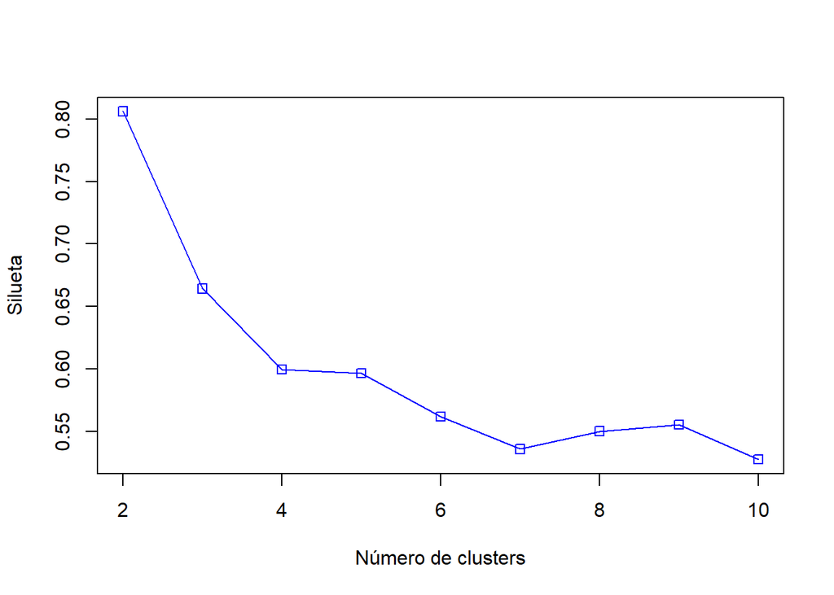

```r
distance <- daisy(hawks_k_means)
resultados <- rep(0, 10)
for (i in c(2,3,4,5,6,7,8,9,10))
{
  fit           <- kmeans(hawks_k_means, i)
  y_cluster     <- fit$cluster
  sk            <- silhouette(y_cluster, distance)
  resultados[i] <- mean(sk[,3])
}
plot(2:10,resultados[2:10],type="o",col="blue",pch=0,xlab="Número de clusters",ylab="Silueta")
```

De acuerdo a los valores de las siluetas, el mejor valor para “k” es 2 a pesar que hay 3 tipos de especie.

Vamos a verificar el número de cluster mediante el procedimiento elbow (codo).

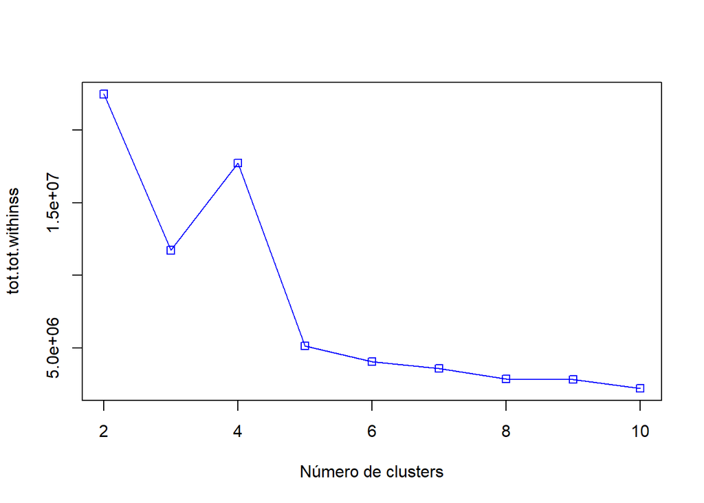

```r
resultados <- rep(0, 10)
  for (i in c(2,3,4,5,6,7,8,9,10))
  {
    fit           <- kmeans(hawks_k_means, i)
    resultados[i] <- fit$tot.withinss
  }
plot(2:10,resultados[2:10],type="o",col="blue",pch=0,xlab="Número de clusters",ylab="tot.tot.withinss")
```

Vamos a utilizar los criterios, silueta media (“asw”) y Calinski-Harabasz (“ch”).

```r
if (!require('fpc')) install.packages('fpc')
library(fpc)

fit_ch  <- kmeansruns(hawks_k_means, krange = 1:10, criterion = "ch")
fit_asw <- kmeansruns(hawks_k_means, krange = 1:10, criterion = "asw")

print(fit_ch$bestk)
```

```
## [1] 10
```

```r
print(fit_asw$bestk)
```

```
## [1] 2
```

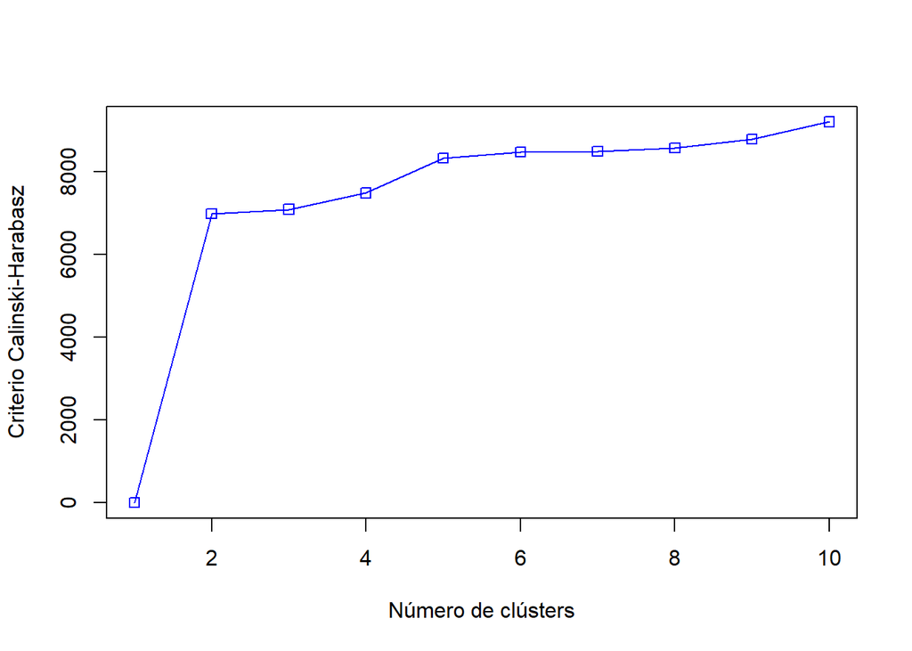

```r
plot(1:10,fit_ch$crit,type="o",col="blue",pch=0,xlab="Número de clústers",ylab="Criterio Calinski-Harabasz")
```

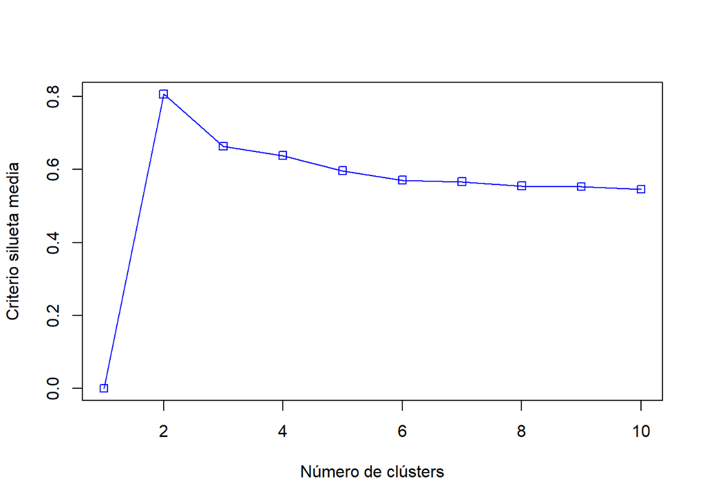

```r
plot(1:10,fit_asw$crit,type="o",col="blue",pch=0,xlab="Número de clústers",ylab="Criterio silueta media")
```

### Aplicación de algoritmo k-means

Aplicamos la función de k-means para 3 clusters:

WEIGHT Y WING

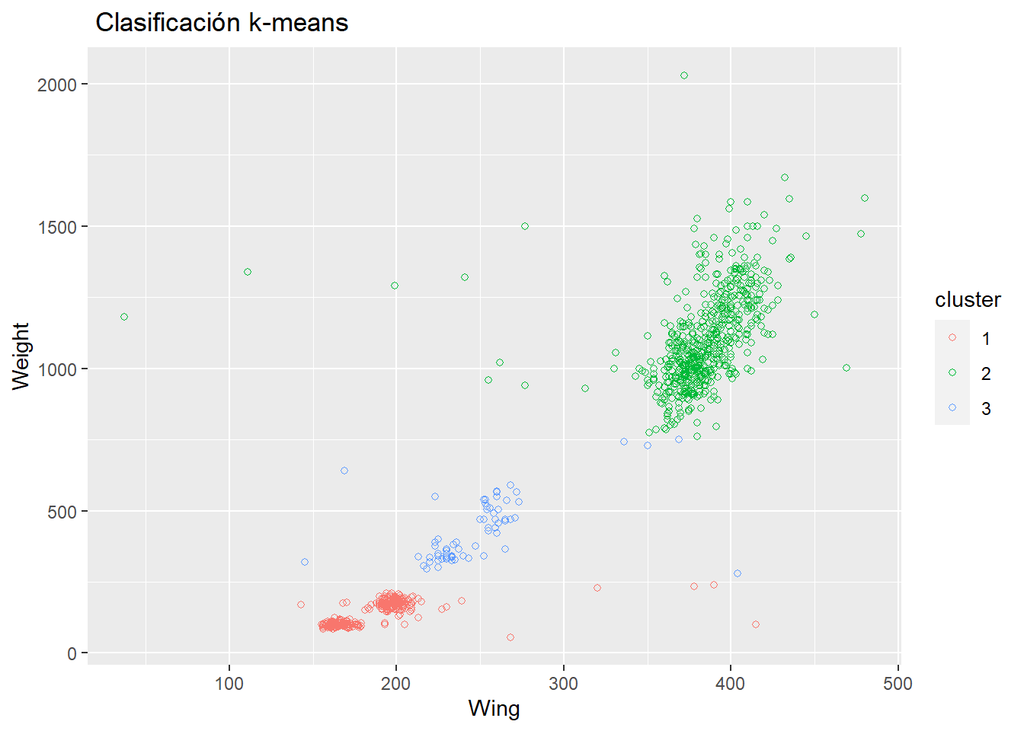

```r
hawks3clusters <- kmeans(hawks_k_means, 3)
hawks_k_means$cluster <- as.character(hawks3clusters$cluster)
ggplot(hawks_k_means) + geom_point(aes(x=Wing, y=Weight, colour=cluster), shape=1) + labs(title= " Clasificación k-means")
```

```r
ggplot(hawks_k_original) + geom_point(aes(x=Wing, y=Weight, colour=Species), shape=9)+ labs(title= " Clasificación real")
```

[output not shown]

HALLUX Y WEIGHT

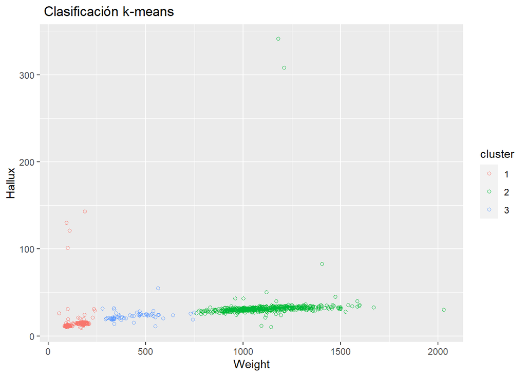

```r
#Hallux and Weight
ggplot(hawks_k_means) + geom_point(aes(x=Weight, y=Hallux, colour=cluster), shape=1) + labs(title= " Clasificación k-means")
```

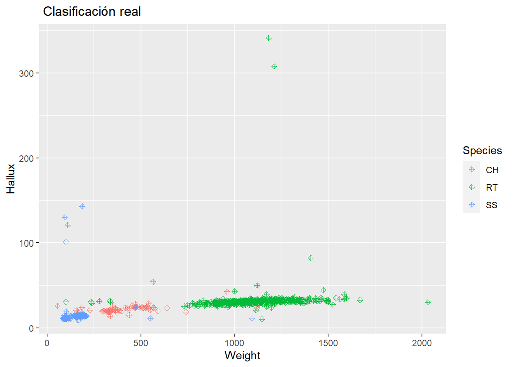

```r
ggplot(hawks_k_original) + geom_point(aes(x=Weight, y=Hallux, colour=Species), shape=9)+ labs(title= " Clasificación real")
```

CULMEN Y WING

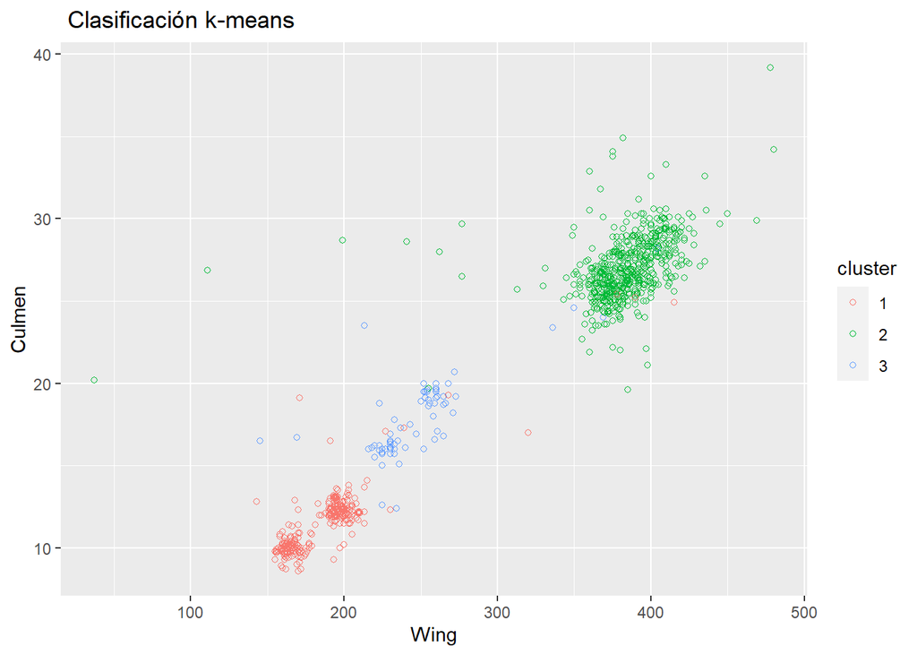

```r
#Culmen and Wing
ggplot(hawks_k_means) + geom_point(aes(x=Wing, y=Culmen, colour=cluster), shape=1) + labs(title= " Clasificación k-means")
```

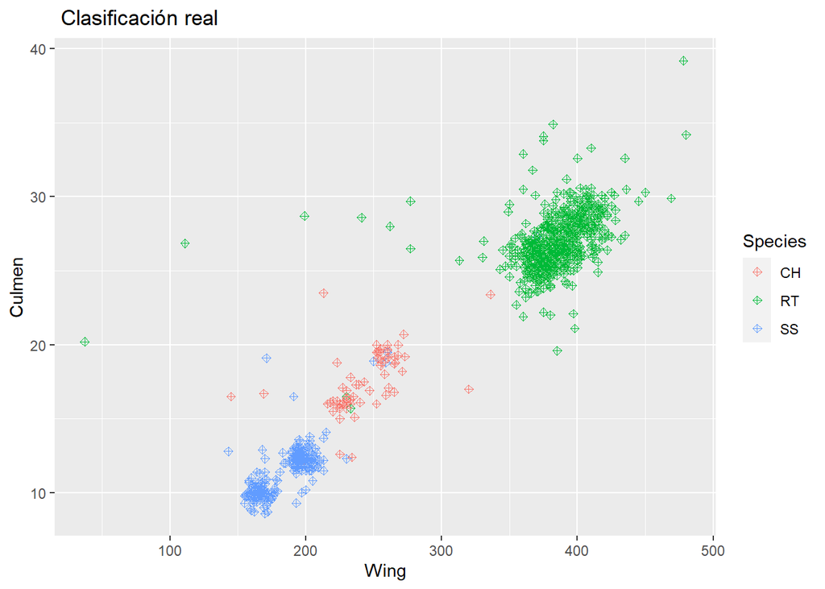

```r
ggplot(hawks_k_original) + geom_point(aes(x=Wing, y=Culmen, colour=Species), shape=9)+ labs(title= " Clasificación real")
```

En todas las gráficas logramos ver los 3 cluster definidos, pero difieren de la clasificación real en como se estan distribuyendo las especies.

Vamos a realizar el mismo ejercicio pero ahora para 4 clusters, solo para Weight and wing: WEIGHT Y WING

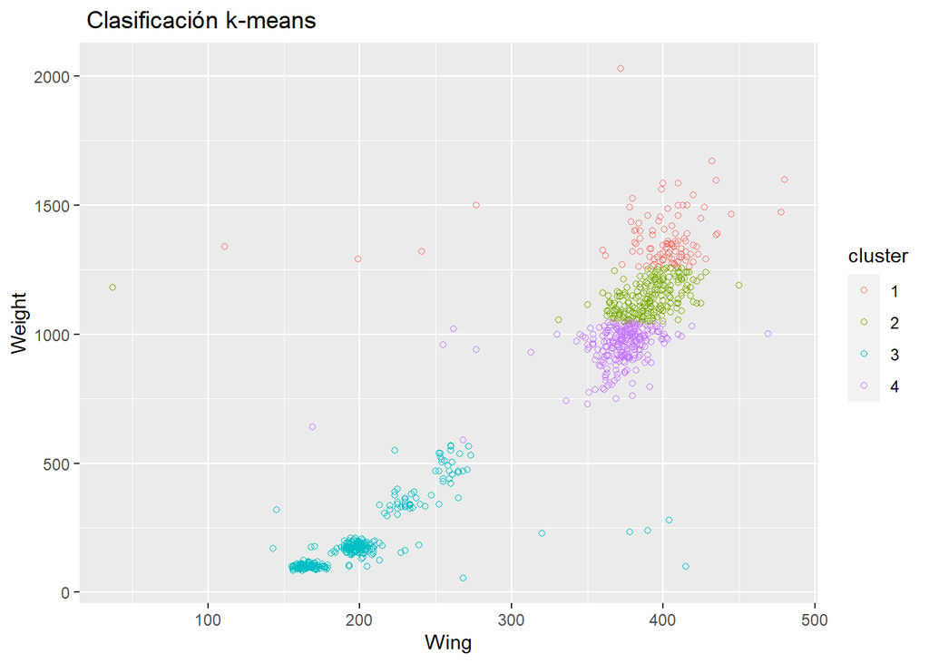

```r
hawks3clusters <- kmeans(hawks_k_means, 4)
hawks_k_means$cluster <- as.character(hawks3clusters$cluster)
ggplot(hawks_k_means) + geom_point(aes(x=Wing, y=Weight, colour=cluster), shape=1) + labs(title= " Clasificación k-means")
```

```r
ggplot(hawks_k_original) + geom_point(aes(x=Wing, y=Weight, colour=Species), shape=9)+ labs(title= " Clasificación real")
```

[output not shown]

Se observan bien diferenciados los 4 cluster e incluso se obtiene una clasificación mas parecida a la grafica real, la excepción es la especie RT del gráfico real, el algoritmo k-means esta encontrando una clasificación mas que en el dato real.

# Ejercicio 2

### Aspectos a evaluar:

- Se aplican lo algoritmos DBSCAN y OPTICS de forma correcta.
- Se prueban con diferentes valores de eps.
- Se obtiene una medida de lo bueno que es el agrupamiento.
- Se describen e interpretan los diferentes clusters obtenidos.
- Se presenta el código y es fácilmente reproducible.

## Algoritmo DBSCAN

Como primer paso, vamos a usar la función “kNNdistplot” para derterminar el valor de “eps”. Comenzamos primero con “WING and WEIGHT” y posteriormente “HALLUX and WEIGHT”

### WING and WEIGHT

[figure not shown]

```r
wing_weight <- dbscan::dbscan(hawks_k_means_dbscan_wing_weight, eps = 50, MinPts =  5)
```

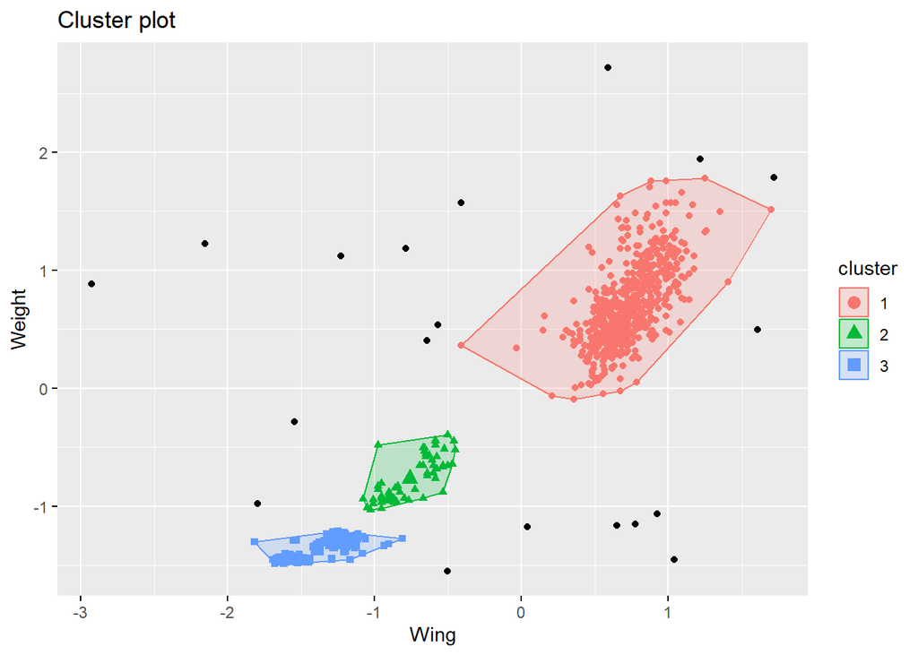

```r
fviz_cluster(wing_weight, hawks_k_means_dbscan_wing_weight, geom = "point")
```

```r
ggplot(hawks_k_original) + geom_point(aes(x=Wing, y=Weight, colour=Species), shape=9)+ labs(title= " Clasificación real")
```

[output not shown]

De acuerdo a los graficos, DBSCAN hace una creación de clusters que son muy parecidos a los de la clasificación real.

### HALLUX and WEIGHT

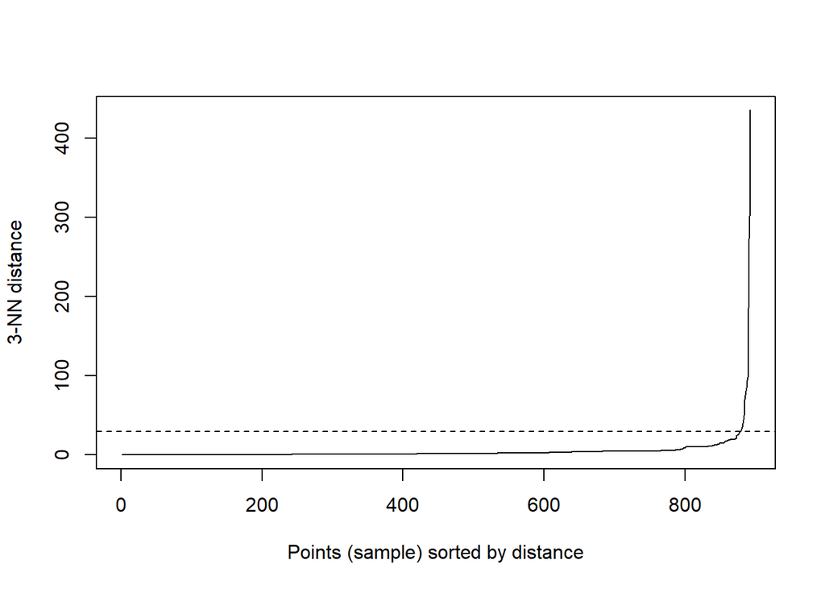

```r
eps_plot = kNNdistplot(hawks_k_means_dbscan_hallux_weight, k=3)
eps_plot %>% abline(h = 30, lty = 2)
```

```r
hallux_weight <- dbscan::dbscan(hawks_k_means_dbscan_hallux_weight, eps = 40, MinPts =  5)
```

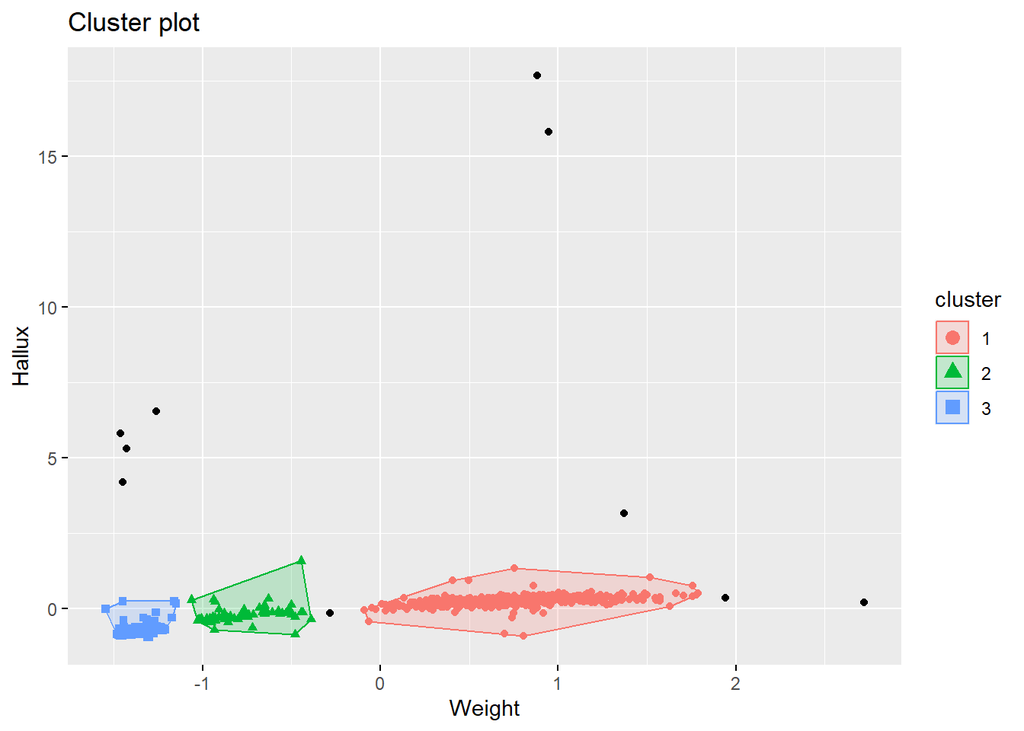

```r
fviz_cluster(hallux_weight, hawks_k_means_dbscan_hallux_weight, geom = "point")
```

Podemos observar que con un valor de eps en 40 se obtienen los 3 clusters que de antemano conocemos.

Hagamos un ejercicio de prueba con un valor de eps en 50

```r
hallux_weight <- dbscan::dbscan(hawks_k_means_dbscan_hallux_weight, eps = 50, MinPts =  6)
```

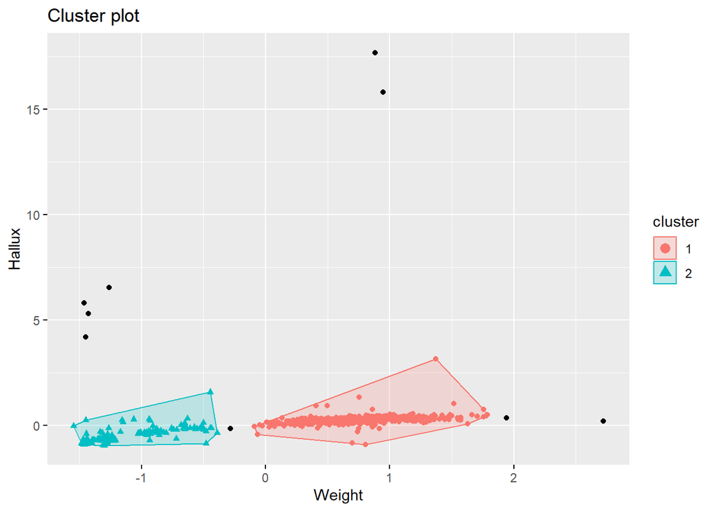

```r
fviz_cluster(hallux_weight, hawks_k_means_dbscan_hallux_weight, geom = "point")
```

Podemos observar que solo se generaron 2 clusters. Este tipo de algoritmo la desventaja que tiene, es que los valores de eps y minPts son muy sensibles y cualquier variación cambia de forma importante los resultados.

## Algoritmo OPTICS

Vamos a iniciar con el diagrama de alcanzabilidad en donde los valles van a representar a los clusters, mientras las cimas serán los outliers.

```r
# hawks_k_means_dbscan_wing_weight_bk <- hawks_k_means_dbscan_wing_weight
```

```r
# hawks_k_means_dbscan_wing_weight <- hawks_k_means_dbscan_wing_weight_bk
#hawks_k_means_dbscan_wing_weight <- scale(hawks_k_means_dbscan_wing_weight)
```

### WING and WEIGHT

```r
opctics_wing_weight <- optics(hawks_k_means_dbscan_wing_weight, minPts = 10)
opctics_wing_weight$order
```

[output not shown]

[output cut: 35 more lines]

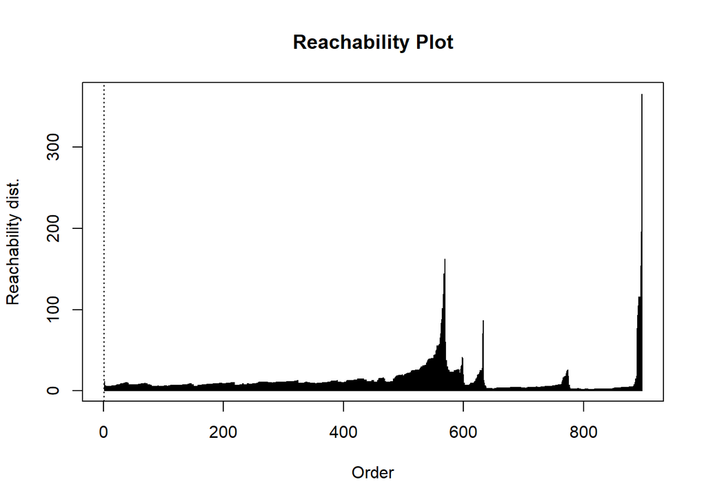

```r
plot(opctics_wing_weight)
```

Cuanto más denso es un clúster, menores serán las distancias de alcanzabilidad y más bajo es el valle.

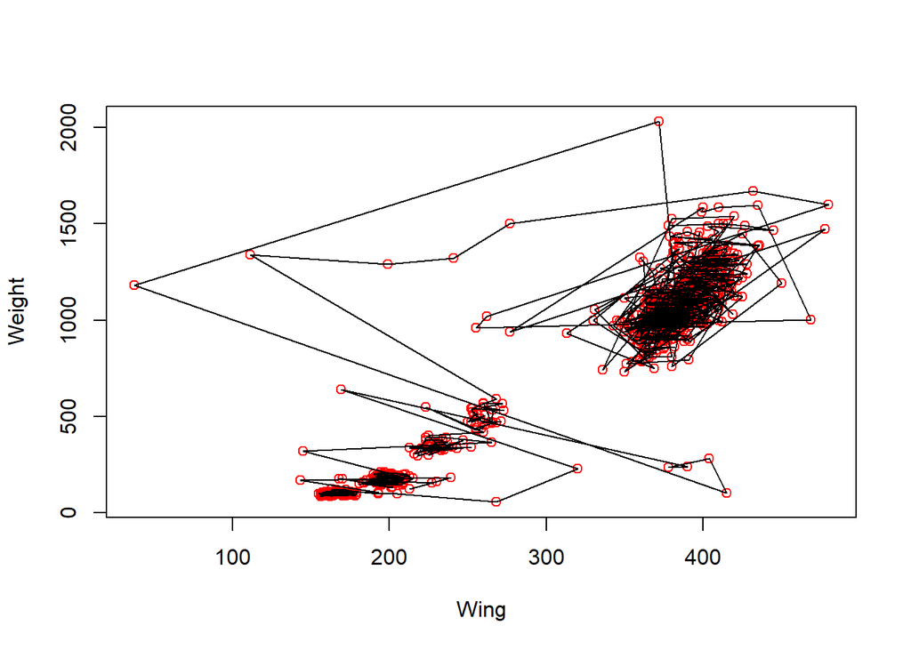

```r
plot(hawks_k_means_dbscan_wing_weight, col = "red")
polygon(hawks_k_means_dbscan_wing_weight[opctics_wing_weight$order,])
```

En este diagrama de alcanzabilidad de tipo “Polygon”, se comienzan a ver de mejor forma los clusters que se podrán formar con las trazas de las distancias entre puntos cercanos del mismo cluster.

### HALLUX and WEIGHT

Hacemos el mismo ejercicio con las columnas “HALLUX and WEIGHT”

```r
opctics_hallux_weight <- optics(hawks_k_means_dbscan_hallux_weight, minPts = 10)
opctics_hallux_weight$order
```

[output not shown]

[output cut: 35 more lines]

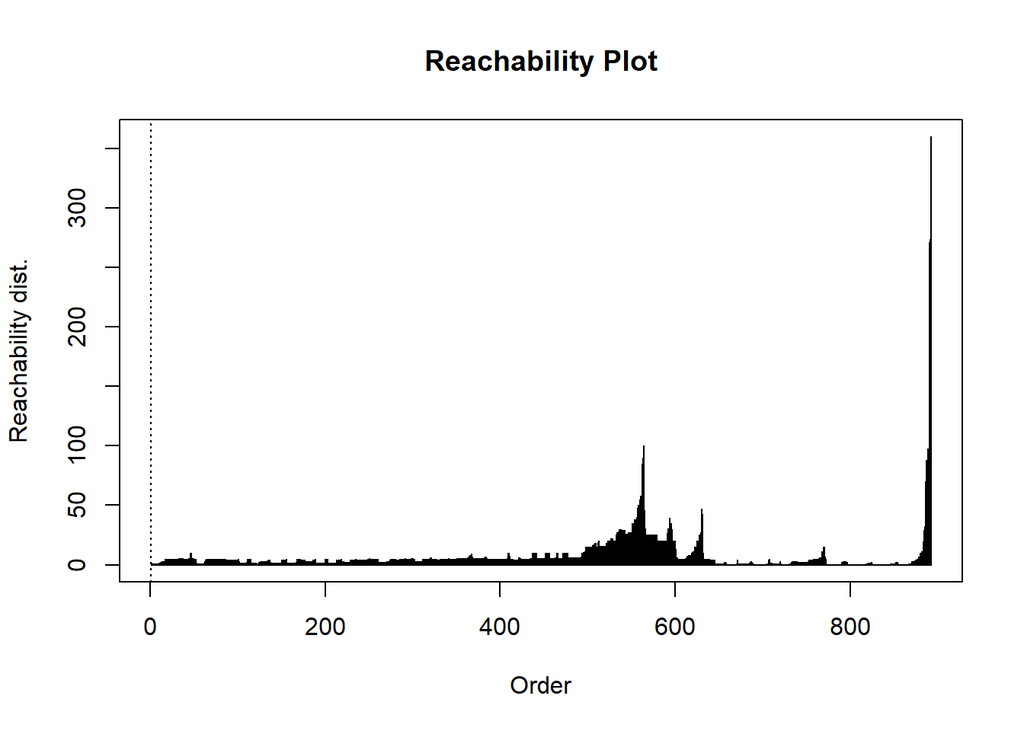

```r
plot(opctics_hallux_weight)
```

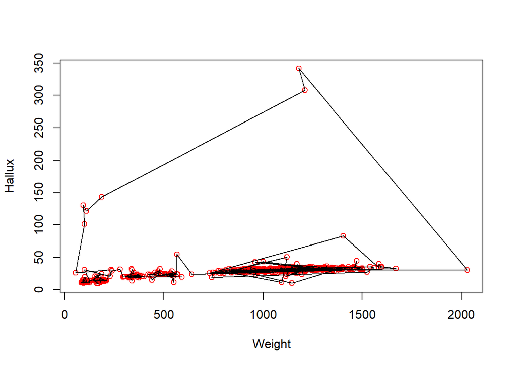

```r
plot(hawks_k_means_dbscan_hallux_weight, col = "red")
polygon(hawks_k_means_dbscan_hallux_weight[opctics_hallux_weight$order,])
```

## extractDBSCAN

Extracción de un clustering DBSCAN cortando la alcanzabilidad en el valor eps_cl

```r
opctics_hallux_weight_dbscan <- extractDBSCAN(opctics_hallux_weight, eps_cl = 40)
opctics_hallux_weight_dbscan
```

```
## OPTICS ordering/clustering for 892 objects.
## Parameters: minPts = 10, eps = 530.001141508205, eps_cl = 40, xi = NA
## The clustering contains 3 cluster(s) and 17 noise points.
##
##   0   1   2   3
##  17 555  65 255
##
## Available fields: order, reachdist, coredist, predecessor, minPts, eps,
##                   eps_cl, xi, cluster
```

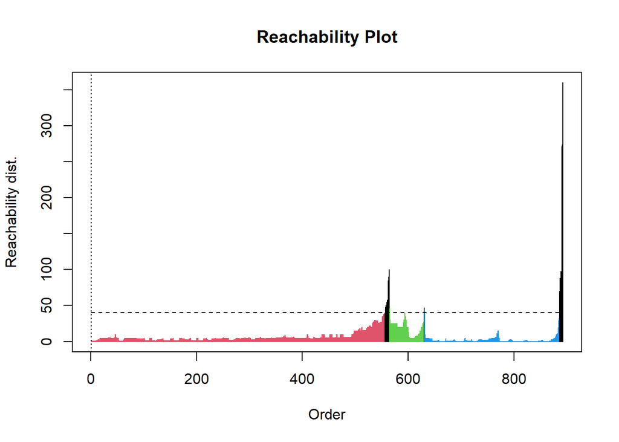

```r
plot(opctics_hallux_weight_dbscan)
```

Podemos observar que se forman 3 clusters, rojo, verde y azul, recordemos que el color negro son los outliers.

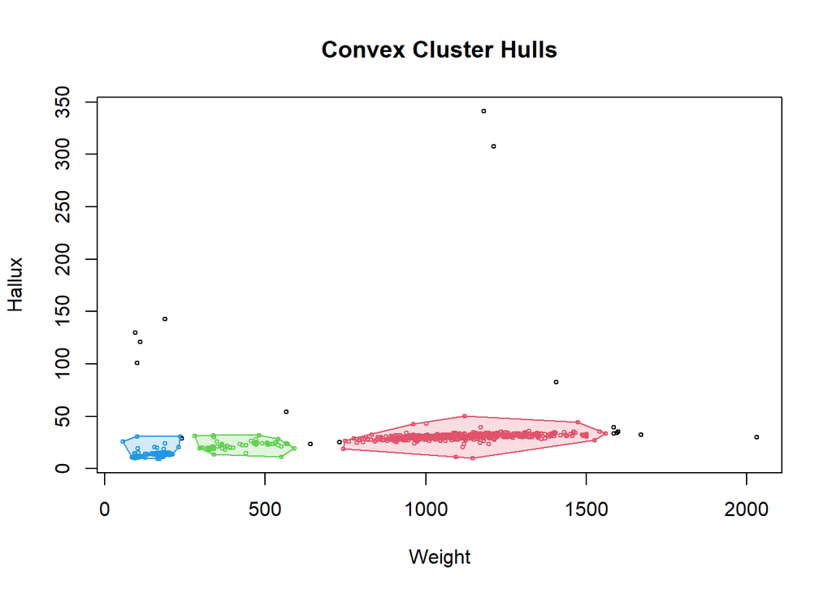

```r
hullplot(hawks_k_means_dbscan_hallux_weight, opctics_hallux_weight_dbscan)
```

Con este gráfico observamos los 3 clusters que corresponden a las especies CH, SS y RT que se observaron en la “Gráfica real” presentada anteriormente.

Hacemos el mismo ejercicio con las columnas “WING and WEIGHT”

```r
opctics_wing_weight_dbscan <- extractDBSCAN(opctics_wing_weight, eps_cl = 50)
opctics_wing_weight_dbscan
```

```
## OPTICS ordering/clustering for 897 objects.
## Parameters: minPts = 10, eps = 531.583483565846, eps_cl = 50, xi = NA
## The clustering contains 3 cluster(s) and 25 noise points.
##
##   0   1   2   3
##  25 554  62 256
##
## Available fields: order, reachdist, coredist, predecessor, minPts, eps,
##                   eps_cl, xi, cluster
```

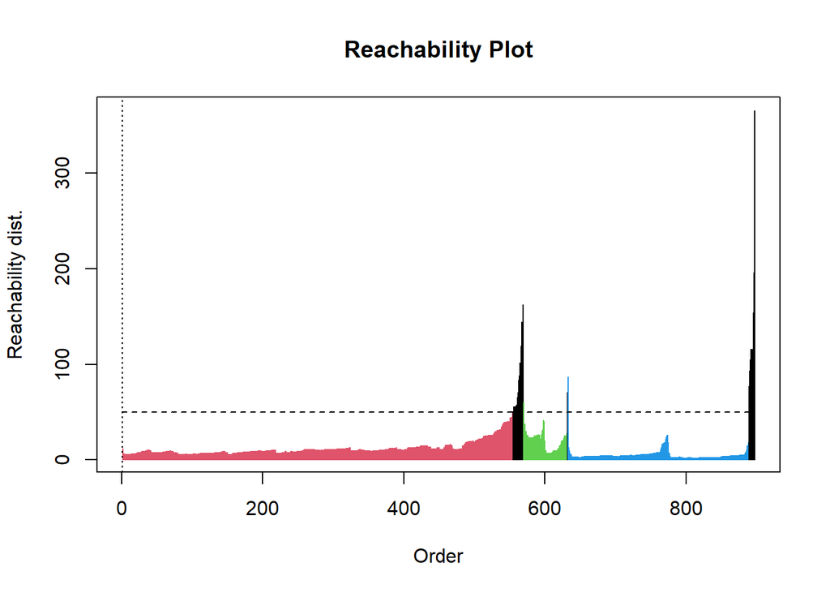

```r
plot(opctics_wing_weight_dbscan)
```

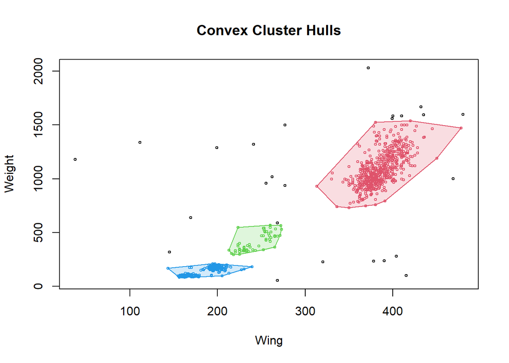

```r
hullplot(hawks_k_means_dbscan_wing_weight, opctics_wing_weight_dbscan)
```

### Extracción del clustering jerárquico en función de la variación de la densidad por el método xi

#### HALLUX and WEIGHT

```r
opctics_hallux_weight_extractXi <- extractXi(opctics_hallux_weight, xi = .3)
opctics_hallux_weight_extractXi
```

```
## OPTICS ordering/clustering for 892 objects.
## Parameters: minPts = 10, eps = 530.001141508205, eps_cl = NA, xi = 0.3
## The clustering contains 12 cluster(s) and 0 noise points.
##
## Available fields: order, reachdist, coredist, predecessor, minPts, eps,
##                   eps_cl, xi, clusters_xi, cluster
```

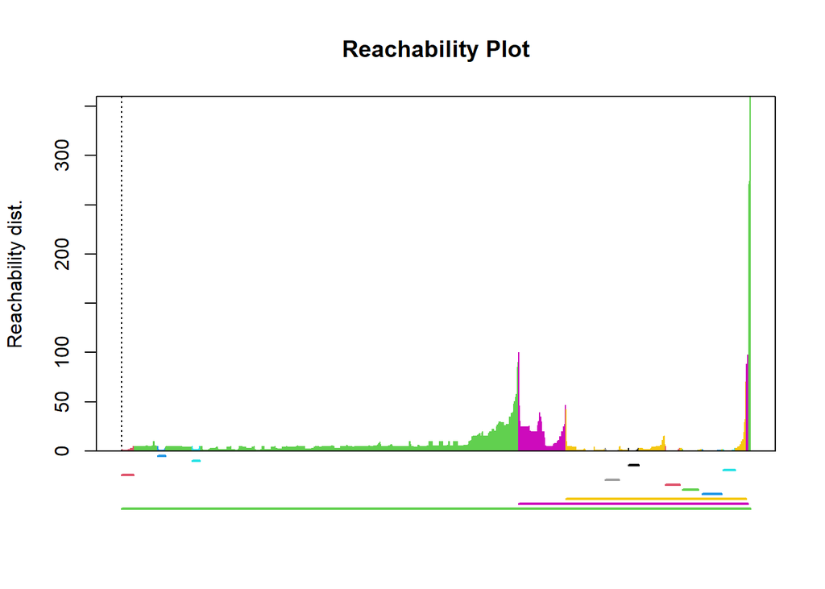

```r
plot(opctics_hallux_weight_extractXi)
```

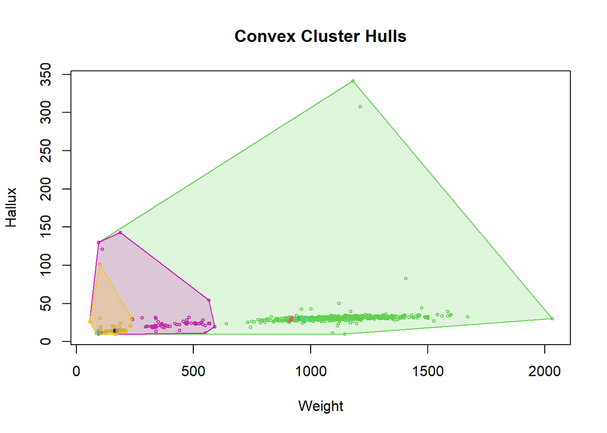

```r
hullplot(hawks_k_means_dbscan_hallux_weight, opctics_hallux_weight_extractXi)
```

#### WING and WEIGHT

```r
opctics_wing_weight_extractXi <- extractXi(opctics_wing_weight, xi = .2)
opctics_wing_weight_extractXi
```

```
## OPTICS ordering/clustering for 897 objects.
## Parameters: minPts = 10, eps = 531.583483565846, eps_cl = NA, xi = 0.2
## The clustering contains 4 cluster(s) and 1 noise points.
##
## Available fields: order, reachdist, coredist, predecessor, minPts, eps,
##                   eps_cl, xi, clusters_xi, cluster
```

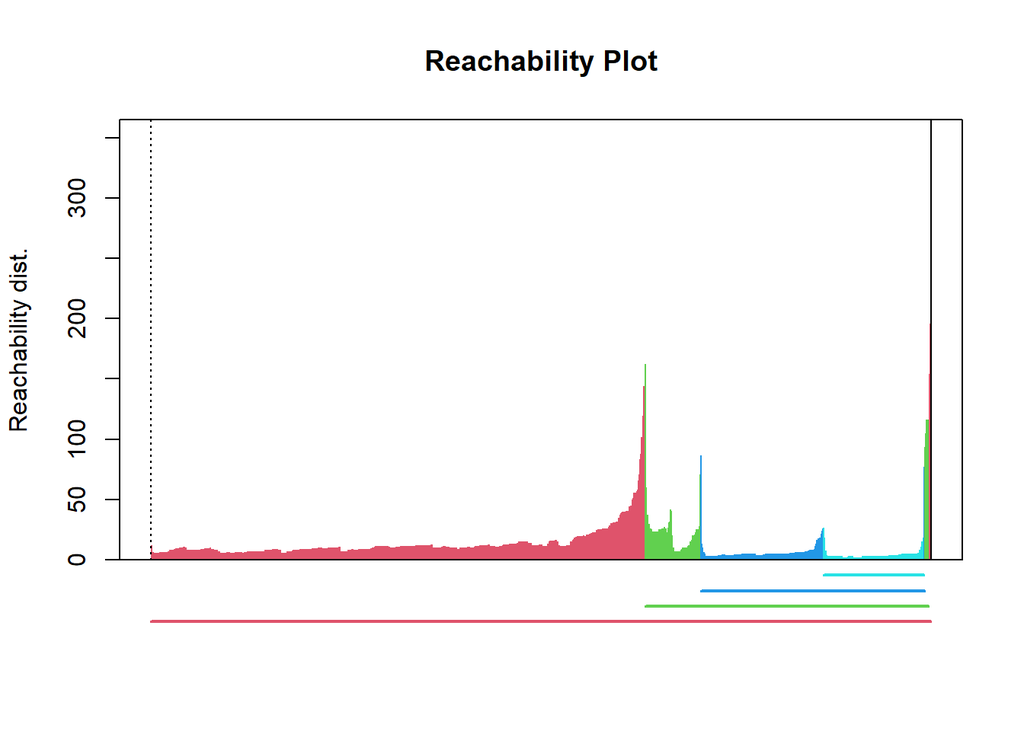

```r
plot(opctics_wing_weight_extractXi)
```

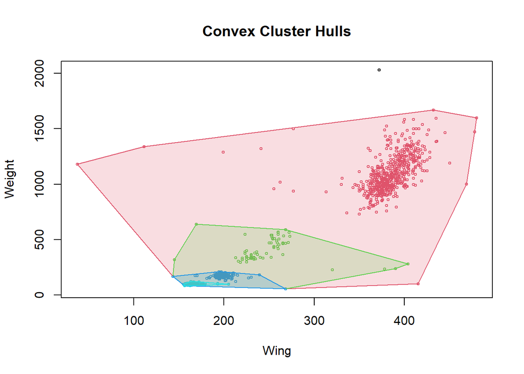

```r
hullplot(hawks_k_means_dbscan_wing_weight, opctics_wing_weight_extractXi)
```

## Ventajas y desventajas de k-means

k-means

Ventajas Buen perfomance con grandes volumnes de datos(Datsets) Facil de usar Clasifica datos aunque estos no tengan algún objetivo definido. Facil interpretación

Desventajas No hace manejo de los outliers, a todo lo pone en al menos un cluster. Solo crea agrupamiento esferico(spherical clusters) Resultados diferentes debido a la inicialización aleatoria del centroide.

Como mitigar las desventajas En los outliers, es algo que se tendría que manejar en el preprocesamiento de los datos, es decir, que cuando apliquemos el algoritmo k-means ya no se tengan dichos outliers. Solo se hace el agrupamiento esférico, considerar otro algoritmo en caso de que se requieran otras figuras para representar a los clusters. Para el caso de la inicialización aleatoria del centroide, se bucaria dejar fijo las pocisiones, auqnue esto no sea algo común.

DBSCAN

Ventajas Puede detectar y gráficar figuras complejas. No se ve afectado por los outliers. El algoritmo y sus parametros son faciles de entender.

Desventajas Como la gran mayoria de los algoritmos Puede tener resultados no deterministicos cuando los parametros no son cofnigurados de forma correcta, por ejemplo el valor de epsilon.

Complejidad al determinar valores de sus parametros, epsilon y puntos minimos.

Como mitigar las desventajas Realizar varias pruebas al momento de determinar los valores, por ejemplo utilzar la función kNNdistplot para saber el valor de epsilon